# Conine data to define strictly-EGA and strictly-maternal genes

Sara Formichetti

EMBL Rome  
sara.formichetti@embl.it

2022-06-15

# 1 Samples’ metadata

Reference paper: [Conine et al., 2018](https://www.sciencedirect.com/science/article/pii/S1534580718305410?via%3Dihub).

| Run | Assay Type | AvgSpotLen | Bases | BioProject | BioSample | Bytes | Center Name | Consent | DATASTORE filetype | DATASTORE provider | DATASTORE region | deveopmental_stage | Experiment | GEO_Accession (exp) | Instrument | LibraryLayout | LibrarySelection | LibrarySource | Organism | Platform | ReleaseDate | rna_injected | Sample Name | source_name | sperm_source | SRA Study | strain |
| --- | --- | --- | --- | --- | --- | --- | --- | --- | --- | --- | --- | --- | --- | --- | --- | --- | --- | --- | --- | --- | --- | --- | --- | --- | --- | --- | --- |
| SRR6838709 | RNA-Seq | 73 | 410911057 | PRJNA438441 | SAMN08716181 | 194361550 | GEO | public | fastq,sra | gs,ncbi,s3 | gs.US,ncbi.public,s3.us-east-1 | 2C embryo | SRX3794574 | GSM3042079 | NextSeq 500 | PAIRED | cDNA | TRANSCRIPTOMIC | Mus musculus | ILLUMINA | 2018-07-26 | none | GSM3042079 | cauda18 | cauda | SRP135754 | FVB |
| SRR6838711 | RNA-Seq | 73 | 421487122 | PRJNA438441 | SAMN08715807 | 199023811 | GEO | public | fastq,sra | gs,ncbi,s3 | gs.US,ncbi.public,s3.us-east-1 | 2C embryo | SRX3794576 | GSM3042081 | NextSeq 500 | PAIRED | cDNA | TRANSCRIPTOMIC | Mus musculus | ILLUMINA | 2018-07-26 | none | GSM3042081 | cauda18 | cauda | SRP135754 | FVB |
| SRR6838713 | RNA-Seq | 73 | 435631082 | PRJNA438441 | SAMN08715805 | 205452048 | GEO | public | fastq,sra | gs,ncbi,s3 | gs.US,ncbi.public,s3.us-east-1 | 2C embryo | SRX3794578 | GSM3042083 | NextSeq 500 | PAIRED | cDNA | TRANSCRIPTOMIC | Mus musculus | ILLUMINA | 2018-07-26 | none | GSM3042083 | cauda18 | cauda | SRP135754 | FVB |
| SRR6838715 | RNA-Seq | 73 | 336261841 | PRJNA438441 | SAMN08715803 | 158282912 | GEO | public | fastq,sra | gs,ncbi,s3 | gs.US,ncbi.public,s3.us-east-1 | 2C embryo | SRX3794580 | GSM3042085 | NextSeq 500 | PAIRED | cDNA | TRANSCRIPTOMIC | Mus musculus | ILLUMINA | 2018-07-26 | none | GSM3042085 | cauda18 | cauda | SRP135754 | FVB |
| SRR6838717 | RNA-Seq | 73 | 355272714 | PRJNA438441 | SAMN08715801 | 167136620 | GEO | public | fastq,sra | gs,ncbi,s3 | gs.US,ncbi.public,s3.us-east-1 | 2C embryo | SRX3794582 | GSM3042087 | NextSeq 500 | PAIRED | cDNA | TRANSCRIPTOMIC | Mus musculus | ILLUMINA | 2018-07-26 | none | GSM3042087 | cauda18 | cauda | SRP135754 | FVB |
| SRR6838719 | RNA-Seq | 73 | 437911331 | PRJNA438441 | SAMN08715799 | 206188528 | GEO | public | fastq,sra | gs,ncbi,s3 | gs.US,ncbi.public,s3.us-east-1 | 2C embryo | SRX3794584 | GSM3042089 | NextSeq 500 | PAIRED | cDNA | TRANSCRIPTOMIC | Mus musculus | ILLUMINA | 2018-07-26 | none | GSM3042089 | cauda18 | cauda | SRP135754 | FVB |
| SRR6838721 | RNA-Seq | 73 | 487569138 | PRJNA438441 | SAMN08715797 | 229408296 | GEO | public | fastq,sra | gs,ncbi,s3 | gs.US,ncbi.public,s3.us-east-1 | 2C embryo | SRX3794586 | GSM3042091 | NextSeq 500 | PAIRED | cDNA | TRANSCRIPTOMIC | Mus musculus | ILLUMINA | 2018-07-26 | none | GSM3042091 | cauda18 | cauda | SRP135754 | FVB |
| SRR6838724 | RNA-Seq | 73 | 521324559 | PRJNA438441 | SAMN08715794 | 244837382 | GEO | public | fastq,sra | gs,ncbi,s3 | gs.US,ncbi.public,s3.us-east-1 | 2C embryo | SRX3794589 | GSM3042094 | NextSeq 500 | PAIRED | cDNA | TRANSCRIPTOMIC | Mus musculus | ILLUMINA | 2018-07-26 | none | GSM3042094 | cauda18 | cauda | SRP135754 | FVB |
| SRR6838725 | RNA-Seq | 73 | 404854043 | PRJNA438441 | SAMN08715793 | 189754022 | GEO | public | fastq,sra | gs,ncbi,s3 | gs.US,ncbi.public,s3.us-east-1 | 2C embryo | SRX3794590 | GSM3042095 | NextSeq 500 | PAIRED | cDNA | TRANSCRIPTOMIC | Mus musculus | ILLUMINA | 2018-07-26 | none | GSM3042095 | cauda18 | cauda | SRP135754 | FVB |
| SRR6838727 | RNA-Seq | 73 | 486923480 | PRJNA438441 | SAMN08715791 | 228456025 | GEO | public | fastq,sra | gs,ncbi,s3 | gs.US,ncbi.public,s3.us-east-1 | 2C embryo | SRX3794592 | GSM3042097 | NextSeq 500 | PAIRED | cDNA | TRANSCRIPTOMIC | Mus musculus | ILLUMINA | 2018-07-26 | none | GSM3042097 | cauda18 | cauda | SRP135754 | FVB |
| SRR6838728 | RNA-Seq | 73 | 338874427 | PRJNA438441 | SAMN08715790 | 159758442 | GEO | public | fastq,sra | gs,ncbi,s3 | gs.US,ncbi.public,s3.us-east-1 | 2C embryo | SRX3794593 | GSM3042098 | NextSeq 500 | PAIRED | cDNA | TRANSCRIPTOMIC | Mus musculus | ILLUMINA | 2018-07-26 | none | GSM3042098 | cauda18 | cauda | SRP135754 | FVB |
| SRR6838730 | RNA-Seq | 73 | 317036240 | PRJNA438441 | SAMN08715788 | 149122612 | GEO | public | fastq,sra | gs,ncbi,s3 | gs.US,ncbi.public,s3.us-east-1 | 2C embryo | SRX3794595 | GSM3042100 | NextSeq 500 | PAIRED | cDNA | TRANSCRIPTOMIC | Mus musculus | ILLUMINA | 2018-07-26 | none | GSM3042100 | cauda18 | cauda | SRP135754 | FVB |
| SRR6838732 | RNA-Seq | 73 | 379892545 | PRJNA438441 | SAMN08715786 | 178965353 | GEO | public | fastq,sra | gs,ncbi,s3 | gs.US,ncbi.public,s3.us-east-1 | 2C embryo | SRX3794597 | GSM3042102 | NextSeq 500 | PAIRED | cDNA | TRANSCRIPTOMIC | Mus musculus | ILLUMINA | 2018-07-26 | none | GSM3042102 | cauda18 | cauda | SRP135754 | FVB |
| SRR6838741 | RNA-Seq | 73 | 171312991 | PRJNA438441 | SAMN08716113 | 80565570 | GEO | public | fastq,sra | gs,ncbi,s3 | gs.US,ncbi.public,s3.us-east-1 | 2C embryo | SRX3794606 | GSM3042111 | NextSeq 500 | PAIRED | cDNA | TRANSCRIPTOMIC | Mus musculus | ILLUMINA | 2018-07-26 | none | GSM3042111 | cauda28 | cauda | SRP135754 | FVB |
| SRR6838742 | RNA-Seq | 73 | 415766020 | PRJNA438441 | SAMN08716112 | 195488370 | GEO | public | fastq,sra | gs,ncbi,s3 | gs.US,ncbi.public,s3.us-east-1 | 2C embryo | SRX3794607 | GSM3042112 | NextSeq 500 | PAIRED | cDNA | TRANSCRIPTOMIC | Mus musculus | ILLUMINA | 2018-07-26 | none | GSM3042112 | cauda28 | cauda | SRP135754 | FVB |
| SRR6838743 | RNA-Seq | 73 | 413091275 | PRJNA438441 | SAMN08715779 | 193612599 | GEO | public | fastq,sra | gs,ncbi,s3 | gs.US,ncbi.public,s3.us-east-1 | 2C embryo | SRX3794608 | GSM3042113 | NextSeq 500 | PAIRED | cDNA | TRANSCRIPTOMIC | Mus musculus | ILLUMINA | 2018-07-26 | none | GSM3042113 | cauda28 | cauda | SRP135754 | FVB |
| SRR6838744 | RNA-Seq | 73 | 369837803 | PRJNA438441 | SAMN08716056 | 175482725 | GEO | public | fastq,sra | gs,ncbi,s3 | gs.US,ncbi.public,s3.us-east-1 | 2C embryo | SRX3794609 | GSM3042114 | NextSeq 500 | PAIRED | cDNA | TRANSCRIPTOMIC | Mus musculus | ILLUMINA | 2018-07-26 | none | GSM3042114 | cauda28 | cauda | SRP135754 | FVB |
| SRR6838745 | RNA-Seq | 73 | 477722843 | PRJNA438441 | SAMN08716055 | 223725545 | GEO | public | fastq,sra | gs,ncbi,s3 | gs.US,ncbi.public,s3.us-east-1 | 2C embryo | SRX3794610 | GSM3042115 | NextSeq 500 | PAIRED | cDNA | TRANSCRIPTOMIC | Mus musculus | ILLUMINA | 2018-07-26 | none | GSM3042115 | cauda28 | cauda | SRP135754 | FVB |
| SRR6838746 | RNA-Seq | 73 | 285995137 | PRJNA438441 | SAMN08716111 | 134611781 | GEO | public | fastq,sra | gs,ncbi,s3 | gs.US,ncbi.public,s3.us-east-1 | 2C embryo | SRX3794611 | GSM3042116 | NextSeq 500 | PAIRED | cDNA | TRANSCRIPTOMIC | Mus musculus | ILLUMINA | 2018-07-26 | none | GSM3042116 | cauda28 | cauda | SRP135754 | FVB |
| SRR6838747 | RNA-Seq | 73 | 458996745 | PRJNA438441 | SAMN08716110 | 216224953 | GEO | public | fastq,sra | gs,ncbi,s3 | gs.US,ncbi.public,s3.us-east-1 | 2C embryo | SRX3794612 | GSM3042117 | NextSeq 500 | PAIRED | cDNA | TRANSCRIPTOMIC | Mus musculus | ILLUMINA | 2018-07-26 | none | GSM3042117 | cauda28 | cauda | SRP135754 | FVB |
| SRR6838748 | RNA-Seq | 73 | 437404278 | PRJNA438441 | SAMN08716109 | 205306427 | GEO | public | fastq,sra | gs,ncbi,s3 | gs.US,ncbi.public,s3.us-east-1 | 2C embryo | SRX3794613 | GSM3042118 | NextSeq 500 | PAIRED | cDNA | TRANSCRIPTOMIC | Mus musculus | ILLUMINA | 2018-07-26 | none | GSM3042118 | cauda28 | cauda | SRP135754 | FVB |
| SRR6838749 | RNA-Seq | 73 | 432663281 | PRJNA438441 | SAMN08716108 | 203605454 | GEO | public | fastq,sra | gs,ncbi,s3 | gs.US,ncbi.public,s3.us-east-1 | 2C embryo | SRX3794614 | GSM3042119 | NextSeq 500 | PAIRED | cDNA | TRANSCRIPTOMIC | Mus musculus | ILLUMINA | 2018-07-26 | none | GSM3042119 | cauda28 | cauda | SRP135754 | FVB |
| SRR6838750 | RNA-Seq | 73 | 271430850 | PRJNA438441 | SAMN08716107 | 127569874 | GEO | public | fastq,sra | gs,ncbi,s3 | gs.US,ncbi.public,s3.us-east-1 | 2C embryo | SRX3794615 | GSM3042120 | NextSeq 500 | PAIRED | cDNA | TRANSCRIPTOMIC | Mus musculus | ILLUMINA | 2018-07-26 | none | GSM3042120 | cauda28 | cauda | SRP135754 | FVB |
| SRR6838751 | RNA-Seq | 73 | 289056462 | PRJNA438441 | SAMN08716106 | 135326595 | GEO | public | fastq,sra | gs,ncbi,s3 | gs.US,ncbi.public,s3.us-east-1 | 2C embryo | SRX3794616 | GSM3042121 | NextSeq 500 | PAIRED | cDNA | TRANSCRIPTOMIC | Mus musculus | ILLUMINA | 2018-07-26 | none | GSM3042121 | cauda28 | cauda | SRP135754 | FVB |
| SRR6838752 | RNA-Seq | 73 | 198157052 | PRJNA438441 | SAMN08716105 | 93120934 | GEO | public | fastq,sra | gs,ncbi,s3 | gs.US,ncbi.public,s3.us-east-1 | 2C embryo | SRX3794617 | GSM3042122 | NextSeq 500 | PAIRED | cDNA | TRANSCRIPTOMIC | Mus musculus | ILLUMINA | 2018-07-26 | none | GSM3042122 | cauda28 | cauda | SRP135754 | FVB |
| SRR6838753 | RNA-Seq | 73 | 379306525 | PRJNA438441 | SAMN08716104 | 177866539 | GEO | public | fastq,sra | gs,ncbi,s3 | gs.US,ncbi.public,s3.us-east-1 | 2C embryo | SRX3794618 | GSM3042123 | NextSeq 500 | PAIRED | cDNA | TRANSCRIPTOMIC | Mus musculus | ILLUMINA | 2018-07-26 | none | GSM3042123 | cauda28 | cauda | SRP135754 | FVB |
| SRR6838758 | RNA-Seq | 73 | 359503656 | PRJNA438441 | SAMN08716099 | 168732505 | GEO | public | fastq,sra | gs,ncbi,s3 | gs.US,ncbi.public,s3.us-east-1 | 2C embryo | SRX3794623 | GSM3042128 | NextSeq 500 | PAIRED | cDNA | TRANSCRIPTOMIC | Mus musculus | ILLUMINA | 2018-07-26 | none | GSM3042128 | cauda28 | cauda | SRP135754 | FVB |
| SRR6838759 | RNA-Seq | 73 | 332979760 | PRJNA438441 | SAMN08716098 | 156165846 | GEO | public | fastq,sra | gs,ncbi,s3 | gs.US,ncbi.public,s3.us-east-1 | 2C embryo | SRX3794624 | GSM3042129 | NextSeq 500 | PAIRED | cDNA | TRANSCRIPTOMIC | Mus musculus | ILLUMINA | 2018-07-26 | none | GSM3042129 | cauda28 | cauda | SRP135754 | FVB |
| SRR6838760 | RNA-Seq | 73 | 396840227 | PRJNA438441 | SAMN08716097 | 186076297 | GEO | public | fastq,sra | gs,ncbi,s3 | gs.US,ncbi.public,s3.us-east-1 | 2C embryo | SRX3794625 | GSM3042130 | NextSeq 500 | PAIRED | cDNA | TRANSCRIPTOMIC | Mus musculus | ILLUMINA | 2018-07-26 | none | GSM3042130 | cauda28 | cauda | SRP135754 | FVB |
| SRR6838761 | RNA-Seq | 73 | 397397399 | PRJNA438441 | SAMN08716096 | 185683658 | GEO | public | fastq,sra | gs,ncbi,s3 | gs.US,ncbi.public,s3.us-east-1 | 2C embryo | SRX3794626 | GSM3042131 | NextSeq 500 | PAIRED | cDNA | TRANSCRIPTOMIC | Mus musculus | ILLUMINA | 2018-07-26 | none | GSM3042131 | cauda28 | cauda | SRP135754 | FVB |
| SRR6838762 | RNA-Seq | 73 | 445383724 | PRJNA438441 | SAMN08716095 | 208536585 | GEO | public | fastq,sra | gs,ncbi,s3 | gs.US,ncbi.public,s3.us-east-1 | 2C embryo | SRX3794627 | GSM3042132 | NextSeq 500 | PAIRED | cDNA | TRANSCRIPTOMIC | Mus musculus | ILLUMINA | 2018-07-26 | none | GSM3042132 | cauda28 | cauda | SRP135754 | FVB |
| SRR6838763 | RNA-Seq | 73 | 423555424 | PRJNA438441 | SAMN08716094 | 197184040 | GEO | public | fastq,sra | gs,ncbi,s3 | gs.US,ncbi.public,s3.us-east-1 | 2C embryo | SRX3794628 | GSM3042133 | NextSeq 500 | PAIRED | cDNA | TRANSCRIPTOMIC | Mus musculus | ILLUMINA | 2018-07-26 | none | GSM3042133 | cauda28 | cauda | SRP135754 | FVB |
| SRR6838764 | RNA-Seq | 73 | 546262484 | PRJNA438441 | SAMN08716093 | 256039773 | GEO | public | fastq,sra | gs,ncbi,s3 | gs.US,ncbi.public,s3.us-east-1 | 2C embryo | SRX3794629 | GSM3042134 | NextSeq 500 | PAIRED | cDNA | TRANSCRIPTOMIC | Mus musculus | ILLUMINA | 2018-07-26 | none | GSM3042134 | cauda28 | cauda | SRP135754 | FVB |
| SRR6838708 | RNA-Seq | 73 | 386621690 | PRJNA438441 | SAMN08716182 | 182695051 | GEO | public | fastq,sra | gs,ncbi,s3 | gs.US,ncbi.public,s3.us-east-1 | 2C embryo | SRX3794573 | GSM3042078 | NextSeq 500 | PAIRED | cDNA | TRANSCRIPTOMIC | Mus musculus | ILLUMINA | 2018-07-26 | none | GSM3042078 | cauda18 | cauda | SRP135754 | FVB |
| SRR6838710 | RNA-Seq | 73 | 388595867 | PRJNA438441 | SAMN08715809 | 183684132 | GEO | public | fastq,sra | gs,ncbi,s3 | gs.US,ncbi.public,s3.us-east-1 | 2C embryo | SRX3794575 | GSM3042080 | NextSeq 500 | PAIRED | cDNA | TRANSCRIPTOMIC | Mus musculus | ILLUMINA | 2018-07-26 | none | GSM3042080 | cauda18 | cauda | SRP135754 | FVB |
| SRR6838712 | RNA-Seq | 73 | 482393873 | PRJNA438441 | SAMN08715806 | 227385131 | GEO | public | fastq,sra | gs,ncbi,s3 | gs.US,ncbi.public,s3.us-east-1 | 2C embryo | SRX3794577 | GSM3042082 | NextSeq 500 | PAIRED | cDNA | TRANSCRIPTOMIC | Mus musculus | ILLUMINA | 2018-07-26 | none | GSM3042082 | cauda18 | cauda | SRP135754 | FVB |
| SRR6838714 | RNA-Seq | 73 | 455708936 | PRJNA438441 | SAMN08715804 | 214564522 | GEO | public | fastq,sra | gs,ncbi,s3 | gs.US,ncbi.public,s3.us-east-1 | 2C embryo | SRX3794579 | GSM3042084 | NextSeq 500 | PAIRED | cDNA | TRANSCRIPTOMIC | Mus musculus | ILLUMINA | 2018-07-26 | none | GSM3042084 | cauda18 | cauda | SRP135754 | FVB |
| SRR6838716 | RNA-Seq | 73 | 352735416 | PRJNA438441 | SAMN08715802 | 166079963 | GEO | public | fastq,sra | gs,ncbi,s3 | gs.US,ncbi.public,s3.us-east-1 | 2C embryo | SRX3794581 | GSM3042086 | NextSeq 500 | PAIRED | cDNA | TRANSCRIPTOMIC | Mus musculus | ILLUMINA | 2018-07-26 | none | GSM3042086 | cauda18 | cauda | SRP135754 | FVB |
| SRR6838718 | RNA-Seq | 73 | 625422599 | PRJNA438441 | SAMN08715800 | 293280874 | GEO | public | fastq,sra | gs,ncbi,s3 | gs.US,ncbi.public,s3.us-east-1 | 2C embryo | SRX3794583 | GSM3042088 | NextSeq 500 | PAIRED | cDNA | TRANSCRIPTOMIC | Mus musculus | ILLUMINA | 2018-07-26 | none | GSM3042088 | cauda18 | cauda | SRP135754 | FVB |
| SRR6838720 | RNA-Seq | 73 | 391596405 | PRJNA438441 | SAMN08715798 | 184618859 | GEO | public | fastq,sra | gs,ncbi,s3 | gs.US,ncbi.public,s3.us-east-1 | 2C embryo | SRX3794585 | GSM3042090 | NextSeq 500 | PAIRED | cDNA | TRANSCRIPTOMIC | Mus musculus | ILLUMINA | 2018-07-26 | none | GSM3042090 | cauda18 | cauda | SRP135754 | FVB |
| SRR6838722 | RNA-Seq | 73 | 428061271 | PRJNA438441 | SAMN08715796 | 201275999 | GEO | public | fastq,sra | gs,ncbi,s3 | gs.US,ncbi.public,s3.us-east-1 | 2C embryo | SRX3794587 | GSM3042092 | NextSeq 500 | PAIRED | cDNA | TRANSCRIPTOMIC | Mus musculus | ILLUMINA | 2018-07-26 | none | GSM3042092 | cauda18 | cauda | SRP135754 | FVB |
| SRR6838723 | RNA-Seq | 73 | 444699930 | PRJNA438441 | SAMN08715795 | 208757571 | GEO | public | fastq,sra | gs,ncbi,s3 | gs.US,ncbi.public,s3.us-east-1 | 2C embryo | SRX3794588 | GSM3042093 | NextSeq 500 | PAIRED | cDNA | TRANSCRIPTOMIC | Mus musculus | ILLUMINA | 2018-07-26 | none | GSM3042093 | cauda18 | cauda | SRP135754 | FVB |
| SRR6838726 | RNA-Seq | 73 | 544401254 | PRJNA438441 | SAMN08715792 | 255448276 | GEO | public | fastq,sra | gs,ncbi,s3 | gs.US,ncbi.public,s3.us-east-1 | 2C embryo | SRX3794591 | GSM3042096 | NextSeq 500 | PAIRED | cDNA | TRANSCRIPTOMIC | Mus musculus | ILLUMINA | 2018-07-26 | none | GSM3042096 | cauda18 | cauda | SRP135754 | FVB |
| SRR6838729 | RNA-Seq | 73 | 379214940 | PRJNA438441 | SAMN08715789 | 178673985 | GEO | public | fastq,sra | gs,ncbi,s3 | gs.US,ncbi.public,s3.us-east-1 | 2C embryo | SRX3794594 | GSM3042099 | NextSeq 500 | PAIRED | cDNA | TRANSCRIPTOMIC | Mus musculus | ILLUMINA | 2018-07-26 | none | GSM3042099 | cauda18 | cauda | SRP135754 | FVB |
| SRR6838731 | RNA-Seq | 73 | 301434415 | PRJNA438441 | SAMN08715787 | 141643256 | GEO | public | fastq,sra | gs,ncbi,s3 | gs.US,ncbi.public,s3.us-east-1 | 2C embryo | SRX3794596 | GSM3042101 | NextSeq 500 | PAIRED | cDNA | TRANSCRIPTOMIC | Mus musculus | ILLUMINA | 2018-07-26 | none | GSM3042101 | cauda18 | cauda | SRP135754 | FVB |
| SRR6838754 | RNA-Seq | 73 | 365841045 | PRJNA438441 | SAMN08716103 | 171714554 | GEO | public | fastq,sra | gs,ncbi,s3 | gs.US,ncbi.public,s3.us-east-1 | 2C embryo | SRX3794619 | GSM3042124 | NextSeq 500 | PAIRED | cDNA | TRANSCRIPTOMIC | Mus musculus | ILLUMINA | 2018-07-26 | none | GSM3042124 | cauda28 | cauda | SRP135754 | FVB |
| SRR6838755 | RNA-Seq | 73 | 508635871 | PRJNA438441 | SAMN08716102 | 237773684 | GEO | public | fastq,sra | gs,ncbi,s3 | gs.US,ncbi.public,s3.us-east-1 | 2C embryo | SRX3794620 | GSM3042125 | NextSeq 500 | PAIRED | cDNA | TRANSCRIPTOMIC | Mus musculus | ILLUMINA | 2018-07-26 | none | GSM3042125 | cauda28 | cauda | SRP135754 | FVB |
| SRR6838756 | RNA-Seq | 73 | 354184734 | PRJNA438441 | SAMN08716101 | 167112344 | GEO | public | fastq,sra | gs,ncbi,s3 | gs.US,ncbi.public,s3.us-east-1 | 2C embryo | SRX3794621 | GSM3042126 | NextSeq 500 | PAIRED | cDNA | TRANSCRIPTOMIC | Mus musculus | ILLUMINA | 2018-07-26 | none | GSM3042126 | cauda28 | cauda | SRP135754 | FVB |
| SRR6838757 | RNA-Seq | 73 | 292341123 | PRJNA438441 | SAMN08716100 | 139811179 | GEO | public | fastq,sra | gs,ncbi,s3 | gs.US,ncbi.public,s3.us-east-1 | 2C embryo | SRX3794622 | GSM3042127 | NextSeq 500 | PAIRED | cDNA | TRANSCRIPTOMIC | Mus musculus | ILLUMINA | 2018-07-26 | none | GSM3042127 | cauda28 | cauda | SRP135754 | FVB |

# 2 Heatmap for quality assessment

After applying the log2(n + 1) transformation, I plot heatmap of normalized counts for top highly expressed genes to check for eventual big sample heterogeneity present in the dataset.

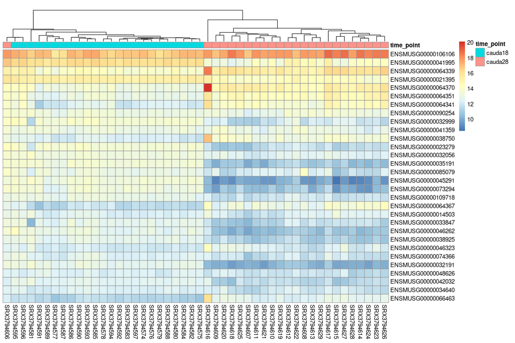

Sample SRX3794606 is an outlier of the 28h time point.

# 3 Finding Differentially Expressed Genes

## 3.1 DESeq2

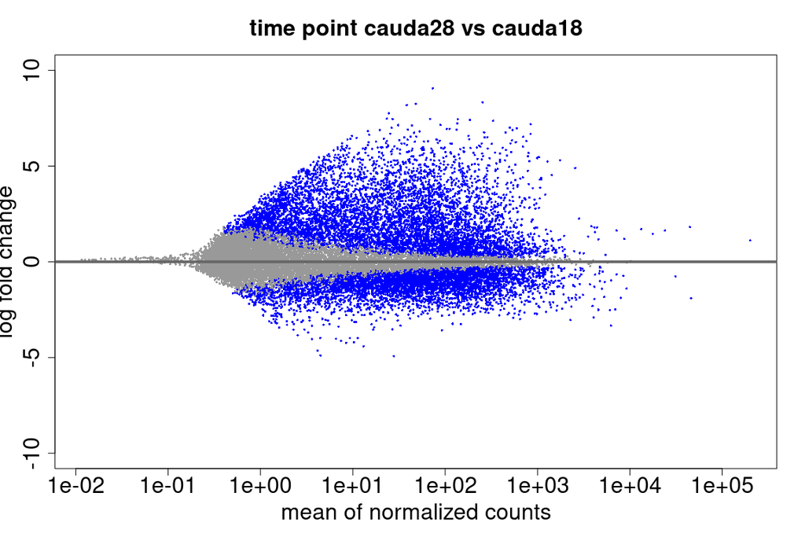

## 3.2 Wilcoxon test, after edgeR normalization

I proceed as advised in [Li et al. Genome Biology 2022](https://genomebiology.biomedcentral.com/articles/10.1186/s13059-022-02648-4#Sec4) for big datasets (e.g. num samples ~ 100):

1. edgeR normalization
2. Wilcoxon non parametric statistical test.

## 3.3 Comparing the 2 methods with EGA genes

- EGA genes are from [Li et al. Nature 2018](https://www.nature.com/articles/s41586-018-0751-5#additional-information) and defined as RPKM oocyte < 0.5 and RPKM 2c > 2
- “DESeq embr” and “edgeR wilcoxo embr” genes are DEGs found with the two methods with log2FC > 1 between the 18h and the 28h 2c
- “DESeq mat” and “edgeR wilcoxo mat” genes are DEGs found with the two methods with log2FC < -1 between the 18h and the 28h 2c

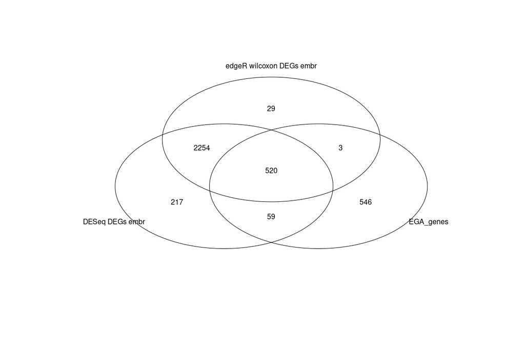

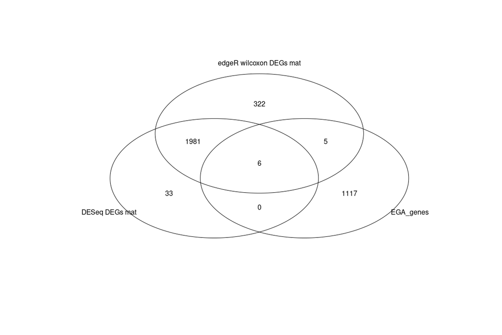

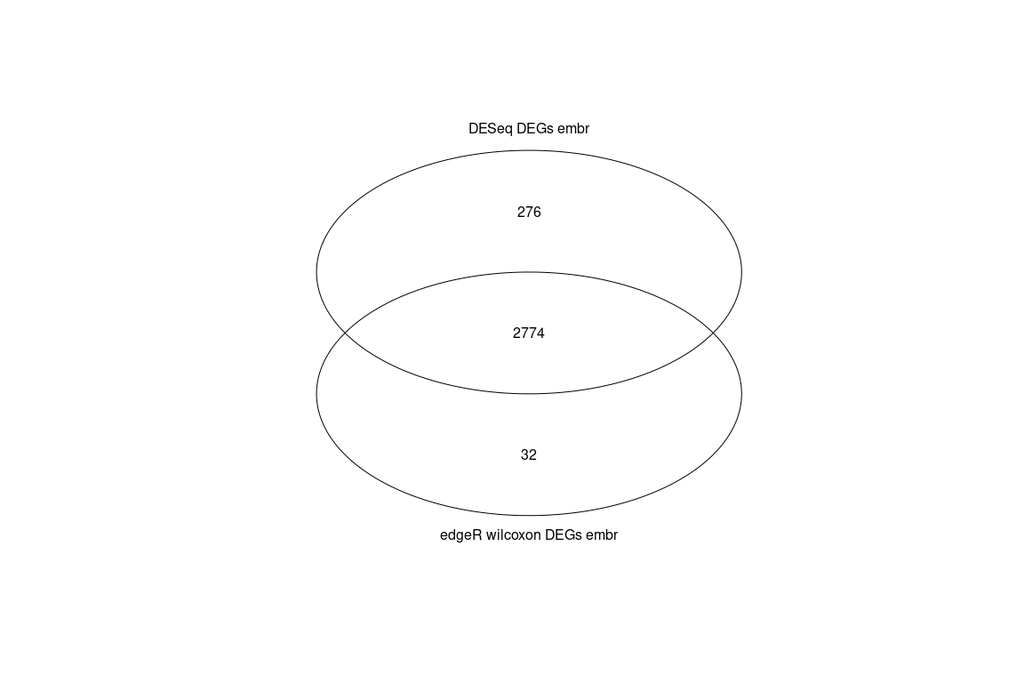

Conclusion: DESeq does find more genes than Wilcoxon test after edgeR, but some of these additional genes are overlapping with EGA genes.

# 4 Defining strictly-EGA and strictly-maternal transcripts

I define: